# Visulaizing A Regression Tree

Gareth Bayvel

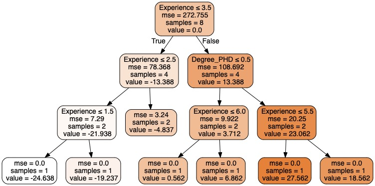

```python
Image('GBoostRegressionFull.jpeg')
```

# Random Forest Refresher

### Building an Random Forest:

**Step One:**

1. Create a Decision Tree with our bootstrapped dataset.
1. To get more variability in our trees, only consider a random subset of explanatory variables at each step.

**Step Two:**

1. Repeat Step One n number of times to build a forest of decision trees.

**Step Three:**  
Estimate the accuracy of the random forest:

- We can now use our Out-of-Bag data as "Unseen Data" to test our RandomForest and measure its accuracy by the proportion of correctly classified OOB samples.
- Our Out-of-Bag error is our proportion of wrong classifications.
- We can no go back to step one bulding a random Forest and instead of using two random columns we can compare the Out-of-Bag error for different number of variables per step.

**Step Four:**  
Select most accurate random forest based upon Out-of-Bag error.

**Important Notes:**

1. Each tree has equal say and are not weighted.
1. Each tree is independent of one another.
1. Trees are usually full length or greater than just a stump (node and two leaves).

```python
Image('RFboost.png')
```

[figure not shown]

## Adaboost Refresher

### Building an AdaBoost Forest:

**Step One:** A first base classifier is trained and used to make predictions on the training set. The relative weight of misclassified training instances is then increased.

**Step Two:**  
A second classifier is trained using the updated weights and again it makes predictions on the training set, weights are updated, and so on.

**Important Notes:**

1. Adaboost Forests are usually just stumps
1. Stumps are trees with a node and two leaves
1. These are weak learners
1. Unlike RF, with Adaboost some stumps are weighted in terms of voting
1. Unlike RF where each tree is independent, with Adaboost order is important
1. By paying more attention to the training instances that the predecessor underfitted a new predictor can correct its predecessor. Resultantly, new predictors focuse more and more on the hard cases.

```python
Image('Adaboost.png')
```

[figure not shown]

# Gradient Boosting

Instead of tweaking the instance weights at every iteration like AdaBoost does, this method tries to fit the new predictor to the residual errors made by the previous predictor.

#### Notably: Gradient Boosting Tree's are Usually larger than a stump but tree size is still restricted (max leaves between 8 and 32)

### Building A Gradient Boosting Forest:

**Step One**:

1. Gradient Boost starts by making a single leaf which is an initial guess for our dependant variable (normally the average).
1. This Initializes our Model with a constant value.

**Step Two**:

1. Calculate the residuals (pseudo-residuals) between the actual observations and our predicted value (initial guess).
1. Fit a regression tree to the residuals (pseudo-residuals) for each Tree we construct.
1. Calculate the output values of each leaf.
1. Make a New Prediction for each sample and Update residuals accordingly

**Step Three**:

1. Repeat the above steps.
1. Our second tree is built based on the residual errors of the first tree.

# Gradient Boost algorithm

#### To solve any supervised Machine Learning problem, given the dataset:

$$\{(x_i,y_i\}_{i=1}^{n}$$

#### And a Differential Loss Function:

$$L(y,f)$$

#### We are trying to find the values of our parameters than minimize our differentiable loss function:

$$\hat f(x) = argmin\sum_{i=1}^{n}[L(y,f(x))]$$

## **Step One**:

#### Initialize Model with A constant Value

$$\hat F_0(x) = \operatorname*{arg\,min}_\gamma\sum_{i=1}^{n}[L(y_i,\gamma)]$$

## **Step Two**:

#### For each Tree we want to construct

For m = 1 to M (number of trees we want to make):

#### A. Compute:

$$ r_{im} = -[\frac{\partial L(y_i,f(x_i))}{\partial f(x_i)}]_{F(x)=F_{m-1}(x)}$$

Where:

- $r_{im}$ is the residual (r)
- for the $i^{th}$ (i) sample
- in the $m^{th}$ tree

#### B. Fit a regression tree to the $r_{im}$ values

Create terminal regions $R_{jm}$ for $j = 1...j_m$

- So we create a regression tree to predict the residuals where our leaves in our new trees are our $R_{jm}$ where j is the index of that leaf and m is the tree

#### C. Output values for each leaf

1. For $j = 1..j_m$ compute: $$\gamma_{jm} = argmin\sum_{x_i\in R_{ij}}{} L(y_i, F_{m-1}(x_i)+\gamma)$$

We are trying to find a $\gamma$ that minimizes the formula above

- ${x_i\in R_{ij}}$ selects only the samples within a specific leaf.

#### D. Updating rule

$$F_m(x) = F_{m-1}(x) + \nu \sum_{j=1}^{J_m} \gamma_{jm}I(x \in R_{jm})$$

where: $\nu$: our learning rate

Sum up all the output values $\gamma_{jm}$ for all the leaves that our x can be found in or is a member of. $$\sum_{j=1}^{J_m} \gamma_{jm}I(x \in R_{jm})$$

## Step Three:

#### Output Final Prediction

$$F_m(x)$$

# Worked Example

#### Data Scientist Salary DataSet: $\{(x_i,y_i\}_{i=1}^{n}$

$$\begin{array}{c|c} Experience & Degree & Salary\\ \hline 2 & Bachelor & 58 \\ \hline 3 & Masters & 72 \\ \hline 3 & Masters & 76 \\ \hline 5 & Bachelor & 80\\ \hline 7 & PHD & 100 \\ \hline 7 & Masters & 87\\ \hline 4 & PHD & 110\\ \hline 1 & Bachelor & 52 \end{array}$$

#### A Differential Loss Function:

The Sum of Squared Residuals is most commonly used as the Loss Function for Gradient Boost because its Partial Derivative is so neat to work with. $$$$

$$\frac{1}{2}(\text{Observed - Predicted})^2$$

#### Partial Derivative w.r.t Predicted

$$\text{Chain and Power Rule} = 2.\frac{1}{2}(\text{Observed - Predicted})\times -1$$$$\frac{\partial L}{\partial \text{Predict}} = -(\text{Observed - Predicted})$$

## **Step One**:

#### Initialize Model with A constant Value

$$\hat F_0(x) = \operatorname*{arg\,min}_\gamma\sum_{i=1}^{n}[L(y_i,\gamma)]$$

#### Find $\gamma$ that Minimizes the Sum below

$$\frac{1}{2}(\text{58 - Predicted})^2 + $$

$$\frac{1}{2}(\text{72 - Predicted})^2+$$

$$\frac{1}{2}(\text{76 - Predicted})^2 + $$

$$\frac{1}{2}(\text{80 - Predicted})^2 + $$

$$\frac{1}{2}(\text{100 - Predicted})^2 + $$

$$\frac{1}{2}(\text{87 - Predicted})^2 + $$$$\frac{1}{2}(\text{110 - Predicted})^2 + $$

$$\frac{1}{2}(\text{52 - Predicted})^2$$

#### Find $\gamma$ By Taking the Partial Derivative of Our Loss Function and Setting Equal to Zero

$$-(\text{58 - Predicted}) + $$

$$-(\text{72 - Predicted})+$$

$$-(\text{76 - Predicted}) + $$

$$-(\text{80 - Predicted}) + $$

$$-(\text{100 - Predicted}) + $$

$$-(\text{87 - Predicted}) + $$$$-(\text{110 - Predicted}) + $$

$$-(\text{52 - Predicted}) = 0$$

$$\text{Predicted} = 79.375$$

#### This means our first leaf predicts all data scientists will have a salary of 79.375

### Step One is Simply Just the Average

Given our loss function $L(y,f)$ the value for gamma that minimizes our cost function for the first iteration is just the average of the observed salaries.

Therefore, we have created the intial predicted value for $F_0(x)$ and this prediction is just a leaf.

# **Step Two**:

#### For each Tree we want to Construct

#### A. Compute:

$$ r_{im} = -[\frac{\partial L(y_i,f(x_i))}{\partial f(x_i)}]_{F(x)=F_{m-1}(x)}$$

#### The middle function is just the partial derivative w.r.t with Predicted variable which we calculated above:

$$[\frac{\partial L(y_i,f(x_i))}{\partial f(x_i)}] = -(\text{Observed - Predicted})$$$$ r_{im} = (Observed-Predicted)_{F(x)=F_{m-1}(x)}$$

### Where m is our first tree

$$(Observed - F_{m-1}(x))$$

$$m = 1$$

$$F_{m-1}(x)) = F_0(x))$$$$F_0(x)) = 79.375$$

### Computing Pseudo-Residuals

Where:

- $r_{im}$ is the residual
- for the $i^{th}$ sample
- in the $m^{th}$ tree

$$r_{1,1} = (58 - 79.375) = -21.375$$$$r_{2,1} = (72 - 79.375 = -7.375$$$$r_{3,1} = (76 - 79.375) = -3.375$$

$$\begin{array}{c|c} Experience & Degree & Salary & \hat{y} & r_{i,1}\\ \hline 2 & Bachelor & 58 & 79.375 & -21.375\\ \hline 3 & Masters & 72 & 79.375 & -7.375\\ \hline 3 & Masters & 76 & 79.375&-3.375\\ \hline 5 & Bachelor & 80& 79.375&0.625\\ \hline 7 & PHD & 100 & 79.375& 20.625\\ \hline 7 & Masters & 87& 79.375&7.625\\ \hline 4 & PHD & 110& 79.375&30.625\\ \hline 1 & Bachelor & 52& 79.375&-27.375 \end{array}$$

#### B. Fit a regression tree to the Residual values

We will build our second tree using our Experience and Degree variables to predict the **residuals**.

1. Just for illustration purposes we will do a few examples but for continuous variables we would normally go through every adjacent pair.
1. Below shows Experience $\leq$3.5 is the best separator for our Root Node as it has the lowest MSE.

## Node Variable Split (Just A Few Examples)

#### Degree_Masters

$$\begin{array}{c|c} & Degree & \text{Pseudo-Residuals}& Mean & (\text{Mean-Residuals})^2\\ \hline &Masters & -7.375& -1.042 & 40.1\\ \hline &Masters &-3.375 & -1.042 & 5.44\\ \hline &Masters & 7.625 & -1.042 & 75.12\\ \hline Sum & & & & 121\\ \hline MSE & & & & {\color{red}{40}} \end{array}$$

#### Degree_Other

$$\begin{array}{c|c} & Degree &\text{Pseudo-Residuals}& Mean & (\text{Mean-Residuals})^2\\ \hline &Bachelor & -21.375& 1.042 & 502\\ \hline &Bachelor & 0.625& 1.042 & 0.17\\ \hline &PHD &20.625 & 1.042 & 383\\ \hline &PHD & 30.625 & 1.042 & 875\\ \hline &Bachelor & -27.375 & 1.042 & 808\\ \hline Sum & & & & 2568\\ \hline MSE & & & & {\color{red}{513}} \end{array}$$

#### Weighted Average

$$\text{Weighted Average} = \frac{3}{5+3}40+ \frac{5}{5+3}513 $$

$$= 335.6 $$

#### Ordered DataSet By Experience

$$\begin{array}{c|c} Experience & Degree & Salary & \hat{y} & r_{i,1}\\ \hline 1 & Bachelor & 52& 79.375&-27.375\\ \hline 2 & Bachelor & 58 & 79.375 & -21.375\\ \hline 3 & Masters & 72 & 79.375 & -7.375\\ \hline 3 & Masters & 76 & 79.375&-3.375\\ \hline 4 & PHD & 110& 79.375&30.625\\ \hline 5 & Bachelor & 80& 79.375&0.625\\ \hline 7 & PHD & 100 & 79.375& 20.625\\ \hline 7 & Masters & 87& 79.375&7.625 \end{array}$$

### Calculate MSE For each Adjacent value

### 3.5

$$\begin{array}{c|c} & Experience & \text{Pseudo-Residuals} & Mean & (\text{Mean-Residuals})^2\\ \hline &1 & -27.375& -14.875 & 156.25\\ \hline &2 &-21.375 &-14.875 & 42.25\\ \hline &3 & -7.375 &-14.875& 56.25\\ \hline &3 & -3.375 &-14.875&132.25\\ Sum & & & & 387\\ \hline MSE & & & & {\color{red}{96.75}} \end{array}$$

$$\begin{array}{c|c} & Experience & \text{Pseudo-Residuals} & Mean & (\text{Mean-Residuals})^2\\ \hline &4 & 30.625&14.875&248\\ \hline &5 & 0.625&14.875& 203\\ \hline &7 & 20.625 &14.875&33\\ \hline &7 & 7.625& 14.875&52.56\\ \hline Sum & & & & 536.56\\ \hline MSE & & & & {\color{red}{134.18}} \end{array}$$

#### Weighted Average

$$\text{Weighted Average} = \frac{4}{4+4}96.75+ \frac{4}{4+4}134.18 $$

$$= 115.47 $$

#### Create terminal regions

$$R_{jm} \quad{}\text{for}\quad{} j = 1...j_m$$

So we create a regression tree to predict the residuals where our leaves in our new trees are our $R_{jm}$ where j is the index of that leaf and m is the tree.

1. The lower left leaf would be our $R_{1,1}$
1. The lower Right leaf would be our $R_{2,1}$

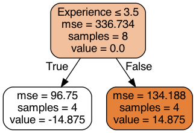

```python
Image('Stump.png')
```

#### C. Output values for each leaf

1. For $j = 1..j_m$ compute: $$\gamma_{jm} = argmin\sum_{x_i\in R_{ij}}{} L(y_i, F_{m-1}(x_i)+\gamma)$$

We are trying to find a $\gamma$ that minimizes the formula above but now we have our predicted value from our first leaf.

- ${x_i\in R_{ij}}$ selects only the samples within a specific leaf.

#### Experience $\leq$3.5

$$\begin{array}{c|c} Experience & Degree & Salary & \hat{y} & r_{i,1}\\ \hline 2 & Bachelor & 58 & 79.375 & -21.375\\ \hline 3 & Masters & 72 & 79.375 & -7.375\\ \hline 3 & Masters & 76 & 79.375&-3.375\\ \hline 1 & Bachelor & 52& 79.375&-27.375 \end{array}$$

### Finding $\gamma$

#### For our First Leaf:

$$\begin{align} \gamma_{1,1} &= \frac{1}{2}((58 -79.375)+\gamma)^{2} \nonumber \\ &\qquad {} + \frac{1}{2}((72 -79.375)+\gamma)^{2}\nonumber \\ &\qquad {} + \frac{1}{2}((58 -79.375)+\gamma)^{2} \nonumber \\ &\qquad {} + \frac{1}{2}((52 -79.375)+\gamma)^{2} \end{align}$$

#### This is just our residuals:

$$\begin{align} \gamma_{1,1} &= \frac{1}{2}(-21.375 - \gamma)^{2} \nonumber \\ &\qquad {} + \frac{1}{2}(-7.375 - \gamma)^{2}\nonumber \\ &\qquad {} + \frac{1}{2}(-3.375 - \gamma)^{2} \nonumber \\ &\qquad {} + \frac{1}{2}(-27.375 - \gamma)^{2} \end{align}$$

#### In terms of their derivatives:

$$4\times\gamma_{1,1} = -21.375 -7.375 -3.375 -27.375$$

$$\gamma_{1,1} = \frac{-21.375 -7.375 -3.375 -27.375}{4}$$

$$\gamma_{1,1} = -14.875$$

#### Experience $\geq$3.5

$$\begin{array}{c|c} Experience & Degree & Salary & \hat{y} & r_{i,1}\\ \hline 5 & Bachelor & 80& 79.375&0.625\\ \hline 7 & PHD & 100 & 79.375& 20.625\\ \hline 7 & Masters & 87& 79.375&7.625\\ \hline 4 & PHD & 110& 79.375&30.625 \end{array}$$

#### For our Second Leaf:

$$\begin{align} \gamma_{2,1} &= \frac{1}{2}((80 -79.375)+\gamma)^{2} \nonumber \\ &\qquad {} + \frac{1}{2}((100 -79.375)+\gamma)^{2}\nonumber \\ &\qquad {} + \frac{1}{2}((87 -79.375)+\gamma)^{2} \nonumber \\ &\qquad {} + \frac{1}{2}((110 -79.375)+\gamma)^{2} \end{align}$$

#### This is just our residuals:

$$\begin{align} \gamma_{2,1} &= \frac{1}{2}(0.625 - \gamma)^{2} \nonumber \\ &\qquad {} + \frac{1}{2}(20.625 - \gamma)^{2}\nonumber \\ &\qquad {} + \frac{1}{2}(7.625 - \gamma)^{2} \nonumber \\ &\qquad {} + \frac{1}{2}(30.625 - \gamma)^{2} \end{align}$$

#### In terms of their derivatives:

$$4\times\gamma_{2,1} = 0.625 +20.625+ 7.625+ 30.625$$

$$\gamma_{2,1} = \frac{0.625 +20.625 7+0.625 +30.625}{4}$$

$$\gamma_{2,1} = 14.875$$

## Output Value of Leaf is Just Average Values of that Leaf

Because of our loss function the residuals of our leaf are the average values of those observations that end up in that leaf.

## Full Sized Tree

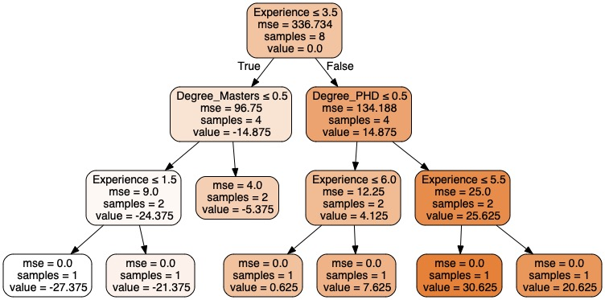

```python
Image('Source.gv.jpeg')
```

## Combining Leaf (Initial guess) and Second Tree to make predictions

Person in red below ended on the bottom middle left leaf with a value of 0.625. If we add that to our average weight (leaf one) we hav:

$$79.375 + 0.625 = 80$$$$\begin{array}{c|c} Experience & Degree & Salary & \hat{y} & r_{i,1}\\ \hline 2 & Bachelor & 58 & 79.375 & -21.375\\ \hline 3 & Masters & 72 & 79.375 & -7.375\\ \hline 3 & Masters & 76 & 79.375&-3.375\\ \hline {\color{red}5}&{\color{red}{Bachelor}}&{\color{red}{80}}&{\color{red}{79.375}}&{\color{red}{0.625}}\\ \hline 7 & PHD & 100 & 79.375& 20.625\\ \hline 7 & Masters & 87& 79.375&7.625\\ \hline 4 & PHD & 110& 79.375&30.625\\ \hline 1 & Bachelor & 52& 79.375&-27.375 \end{array}$$

1. This is suspicious as our data is overfitting our training data and will not generalize well on new data.

### Solution

Gradient Boost uses a learning rate to scale the contribution from the new tree

If our learning rate is 0.1 then:

$$79.375 + 0.1(0.625) = 79.4375$$

This is better than our original leaf and shows a step in the correct direction. Taking smaller steps in the right direction results in better predictions and lower variance.

### D. Updating rule

$$F_m(x) = F_{m-1}(x) + \nu \sum_{j=1}^{J_m} \gamma_{jm}I(x \in R_{jm})$$

where: $\nu$: our learning rate

#### Sum up all the output values $\gamma_{jm}$ for all the leaves that our x can be found in or is a member of.

$$\sum_{j=1}^{J_m} \gamma_{jm}I(x \in R_{jm})$$

#### For our red Observation above:

$$79.375 + 0.1(0.625) = 79.4375$$$$$$

Our prediction is thus 79.4375 which is moving closer to 80 than our inital prediction of 79.375.

## Building Another Tree On Updated Residuals

We calculate our residuals again by running each observations through the first and second tree and scale by 0.1

$$\begin{array}{c|c} Experience & Degree & Salary & \hat{y}& r_{i,2}\\ \hline 2 & Bachelor & 58 & 79.375 & -19.2375\\ \hline 3 & Masters & 72 & 79.375 & -6.6375\\ \hline 3 & Masters & 76 & 79.375&-3.0375\\ \hline 5&Bachelor&80&79.375&0.5625\\ \hline 7 & PHD & 100 & 79.375& 18.5625\\ \hline 7 & Masters & 87& 79.375&6.8625\\ \hline 4 & PHD & 110& 79.375&27.5625\\ \hline 1 & Bachelor & 52& 79.375&-24.6375 \end{array}$$

#### Ordered DataSet By Experience

$$\begin{array}{c|c} Experience & Degree & Salary & \hat{y} & r_{i,1}\\ \hline 1 & Bachelor & 52& 79.375&-24.6375\\ \hline 2 & Bachelor & 58 & 79.375 & -19.2375\\ \hline 3 & Masters & 72 & 79.375 & -6.6375\\ \hline 3 & Masters & 76 & 79.375&-3.0375\\ \hline 4 & PHD & 110& 79.375&27.5625\\ \hline 5&Bachelor&80&79.375&0.5625\\ \hline 7 & PHD & 100 & 79.375& 18.5625\\ \hline 7 & Masters & 87& 79.375&6.8625\\ \end{array}$$

### Calculate MSE For each Adjacent value

### 3.5

$$\begin{array}{c|c} & Experience & \text{Pseudo-Residuals} & Mean & (\text{Mean-Residuals})^2\\ \hline &1 & -24.6375& -13.388 & 115.7\\ \hline &2 &-19.2375 &-13.388 & 28.6\\ \hline &3 & -6.6375 &-13.388& 52.45\\ \hline &3 & -3.0375 &-13.388&117.56\\ Sum & & & & 313\\ \hline MSE & & & & {\color{red}{78.368}} \end{array}$$

$$\begin{array}{c|c} & Experience & \text{Pseudo-Residuals} & Mean & (\text{Mean-Residuals})^2\\ \hline &4 & 27.5625&13.388&199\\ \hline &5 & 0.5625&13.388& 166\\ \hline &7 & 18.5625 &13.388&26.7\\ \hline &7 & 6.8625& 13.388&42\\ \hline Sum & & & & 434\\ \hline MSE & & & & {\color{red}{108.6}} \end{array}$$

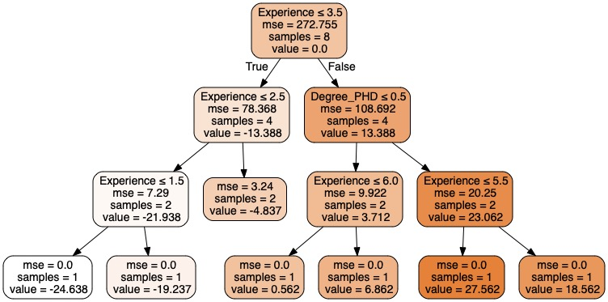

```python
Image('GBoostRegressionFull.jpeg')
```

## Combining Leaf (Initial guess),Second Tree, and Third Tree to make predictions

$$\begin{array}{c|c} Experience & Degree & Salary & \hat{y}& r_{i,1}\\ \hline 2 & Bachelor & 58 & 79.375 & -19.2375\\ \hline 3 & Masters & 72 & 79.375 & -6.6375\\ \hline 3 & Masters & 76 & 79.375&-3.0375\\ \hline {\color{red}5}&{\color{red}{Bachelor}}&{\color{red}{80}}&{\color{red}{79.375}}&{\color{red}{0.5625}}\\ \hline 7 & PHD & 100 & 79.375& 18.5625\\ \hline 7 & Masters & 87& 79.375&6.8625\\ \hline 4 & PHD & 110& 79.375&27.5625\\ \hline 1 & Bachelor & 52& 79.375&-24.6375 \end{array}$$

Person in red above ended on the bottom middle left leaf with a value of 0.562. If we add that to our average weight (leaf one) we have:

$$ 79.375 + 0.1(0.625) +0.1(0.562) = 79.4937$$

We repeat these steps until we have a perfect match or our residuals are so small that we stop.

# Prediction

#### Run the data through all our trees to get the output

# Appendix

**Libraries**:

```
import numpy as np
import matplotlib.pyplot as plt
from sklearn.metrics import r2_score
from sklearn.model_selection import GridSearchCV
from sklearn.datasets import make_regression
import matplotlib.lines as mlines
from sklearn.model_selection import train_test_split
from sklearn.metrics import confusion_matrix,accuracy_score
from sklearn.tree import DecisionTreeClassifier, DecisionTreeRegressor
import seaborn as sns
import pandas as pd
import scipy
from IPython.display import display
from IPython.display import Image
from sklearn.datasets import make_regression
from sklearn import tree
import graphviz
from sklearn.ensemble import RandomForestClassifier, RandomForestRegressor
from sklearn.ensemble import VotingClassifier
from sklearn.linear_model import LogisticRegression
from sklearn.svm import SVC
from sklearn.ensemble import BaggingClassifier
from mlxtend.plotting import plot_decision_regions
```

**Visualizing Regression Tree**:

```
dummy_boost = pd.get_dummies(boost_df, drop_first=True)
X = dummy_boost.drop(['Salary','Residual'],axis=1).values
y = dummy_boost['Residual'].values
fn = dummy_boost.columns[[0,3,4]]
rf_clf = DecisionTreeRegressor()
rf_clf = rf_clf.fit(X,y)

dot_data = tree.export_graphviz(rf_clf, out_file=None,
                     feature_names= fn,
                     filled=True, rounded=True,
                    special_characters=True)
m = graphviz.Source(dot_data)
m.format = 'jpeg'
m.filename = 'GBoostRegressionFull'
m.render()
```

**creating a dataframe**:

```
# creating a dataframe
boost_df = pd.DataFrame({'Experience':[2,3,3,5,7,7,1],'Degree':['Bachelor','Masters','Masters','Bachelor','PHD','Masters','Bachelor',],
                          'Salary': [58,72,76,80,100,87,52]})


boost_dummies = pd.get_dummies(boost_df,drop_first=True)

X = boost_dummies.drop('Salary',axis=1).values
y = boost_dummies['Salary'].values

fn = boost_dummies.columns[[0,2,3]]

clf = RandomForestRegressor(max_depth = 1)
clf = clf.fit(X,y)

fig, axes = plt.subplots(nrows = 1,ncols = 4,figsize = [12,5], dpi=900)
for index in range(0, 4):
    tree.plot_tree(clf.estimators_[index],
                   filled = True,
                   feature_names = fn,
                   ax = axes[index]);

    axes[index].set_title('Estimator: ' + str(index), fontsize = 11)
```

**Second Tree**:

```
boost_df = pd.DataFrame({'Experience':[2,3,3,5,7,7,4,1],'Degree':['Bachelor','Masters','Masters','Bachelor','PHD','Masters','PHD','Bachelor'],
                          'Salary': [58,72,76,80,100,87,110,52]})

# Our Dependant variable is continuous so we calculate average weight
avg_Salary = np.mean(boost_df['Salary'])

# residual (Observed - Predicted)
boost_df['Residual'] = boost_df['Salary'] - avg_Salary

dummy_boost = pd.get_dummies(boost_df, drop_first=True)
X = dummy_boost.drop(['Salary','Residual'],axis=1).values
y = dummy_boost['Residual'].values
fn = dummy_boost.columns[[0,3,4]]
rf_clf = DecisionTreeRegressor(max_depth = 1)
rf_clf = rf_clf.fit(X,y)

dot_data = tree.export_graphviz(rf_clf, out_file=None,
                     feature_names= fn,
                     filled=True, rounded=True,
                    special_characters=True)
g = graphviz.Source(dot_data)

g.format = 'png'
g.filename = 'Stump'
g.render()
```